# Regresi Linier Berganda

Team 2

2025-07-17

# Pendahuluan

## R Package

R package adalah kumpulan fungsi, kode, data, dan dokumentasi yang dirancang untuk memperluas kemampuan bahasa pemrograman R. Dalam R, package berperan serupa seperti library dalam bahasa pemrograman lain seperti Python, yaitu menyediakan sekumpulan alat atau fungsi yang siap pakai untuk menyelesaikan tugas-tugas tertentu tanpa perlu menulis kode dari awal.

## Regresi Linier Berganda

Regresi linier berganda multivariate dengan metode Ordinary Least Square (OLS) adalah teknik statistik yang digunakan untuk memodelkan hubungan linear antara satu variabel dependen dengan dua atau lebih variabel independen (bebas). Tujuannya untuk mengestimasi parameter model regresi yang meminimalkan jumlah kuadrat dari selisih antara nilai observasi dan nilai prediksi (error).

## Persamaan Model

Model regresi linier berganda dapat ditulis sebagai:

$$Y = \beta_0 + \beta_1X_1 + \beta_2X_2 +
\cdots + \beta_nX_n + \epsilon$$

Dimana:

- $Y$: Variabel dependen
- $X_1, X_2, \ldots, X_n$: Variabel independen
- $\beta_0$: Intercept
- $\beta_1, \beta_2, \ldots, \beta_n$: Koefisien regresi
- $\epsilon$: Error term

# Representasi Matriks

Dalam bentuk matriks:

$$\mathbf{Y} =
\mathbf{X}\boldsymbol{\beta} + \boldsymbol{\epsilon}$$

Estimasi koefisien menggunakan ordinary least squares (OLS):

$$\hat{\boldsymbol{\beta}} =
(\mathbf{X}^T\mathbf{X})^{-1}\mathbf{X}^T\mathbf{Y}$$

# Asumsi Model Regresi Linier Berganda OLS

Asumsi yang harus dipenuhi agar estimasi OLS valid dan efisien:

- Model regresi linier dalam parameter (liniearitas).
- Nilai rata-rata error adalah nol $E(\epsilon) = 0$.
- Variansi error konstan (homoskedastisitas).
- Tidak ada autokorelasi error.
- Tidak terjadi multikolinearitas antara variabel bebas.
- Error berdistribusi normal.

# Implementasi Regresi Berganda di R

### Studi Kasus 1

Seorang peneliti pertanian di Kabupaten Pesisir Selatan ingin memahami bagaimana jumlah pupuk yang digunakan dan luas lahan tanam dapat mempengaruhi hasil panen padi petani di wilayah tersebut.

sumber: BPS

```r
# Contoh data
library(MyOLS)  # Package buatan sendiri

hasil.panen <- read.csv2("D:/Kuliah/SEMESTER 3/ART/data panen pesisir selatan.csv", sep = ";")
hasil.panen
```

```
##      Pupuk Luas_tanam Hasil_panen
## 1  1207.58     3990.2    21741.68
## 2   755.97     2254.9    13987.07
## 3  1159.76     3593.6    16098.26
## 4   1585.3     4529.4       28236
## 5  1662.33     4749.5    26500.56
## 6  3098.84     8885.8    44024.62
## 7  2876.27     8260.9    42557.69
## 8  3588.03    10251.5    49336.77
## 9  2440.42     6997.6    34661.01
## 10  1724.1       4926    25424.43
## 11 1451.52     4147.2    18857.21
## 12 2308.04     6594.4    35227.81
## 13  580.62     1658.9     8951.47
## 14  1245.9     3559.7    17238.58
```

```r
hasil.panen <- na.omit(hasil.panen)

 # Konversi tipe kolom yang seharusnya numerik
 hasil.panen$Pupuk <- as.numeric(hasil.panen$Pupuk)
 hasil.panen$Luas_tanam <- as.numeric(hasil.panen$Luas_tanam)
 hasil.panen$Hasil_panen <- as.numeric(hasil.panen$Hasil_panen)

 # Buat X dengan intercept otomatis
 X <- model.matrix(~Pupuk + Luas_tanam, data = hasil.panen)
 Y <- matrix(as.numeric(hasil.panen$Hasil_panen), ncol = 1)

 # Jalankan OLS
 model <- ols_fit(X, Y)

 # Hasil
 print(model$coefficients)
```

```
##                    [,1]
## (Intercept) 2071.637760
## Pupuk          3.042110
## Luas_tanam     3.705727
```

```r
 # Prediksi
 prediksi_Y <- predict_ols(model, X)
 head(prediksi_Y)
```

```
##       [,1]
## 1 20531.82
## 2 12727.43
## 3 18916.66
## 4 23679.01
## 5 24728.98
## 6 44427.00
```

## Membuat Model OLS

```r
model_lm <- lm(Hasil_panen ~ Pupuk + Luas_tanam, data = hasil.panen)
summary(model_lm)
```

```
##
## Call:
## lm(formula = Hasil_panen ~ Pupuk + Luas_tanam, data = hasil.panen)
##
## Residuals:
##     Min      1Q  Median      3Q     Max
## -2998.5 -1488.0  -274.5  1247.2  4557.0
##
## Coefficients:
##             Estimate Std. Error t value Pr(>|t|)
## (Intercept) 2071.638   1572.838   1.317    0.215
## Pupuk          3.042     11.924   0.255    0.803
## Luas_tanam     3.706      4.241   0.874    0.401
##
## Residual standard error: 2253 on 11 degrees of freedom
## Multiple R-squared:  0.9715, Adjusted R-squared:  0.9664
## F-statistic: 187.8 on 2 and 11 DF,  p-value: 3.146e-09
```

## Interpretasi Output

### Model Linier hasil panen

$$Y = 2071.648 + 3.0421Pupuk +
3.7057Luastanam$$
artinya: jika jumlah pupuk dan luas tanam sama dengan 0, maka hasil panen diprediksi sebesar 2071.648 kg.

$$R^2=0.9715$$
sekitar 97.15% variasi hasil panen bisa dijelaskan oleh jumlah pupuk dan luas tanam sisanya 2.85% dijelaskan oleh faktor-faktor lain yang belum dimasukkan kedalam model.

# Diagnostik Model

## Mengecek Asumsi OLS

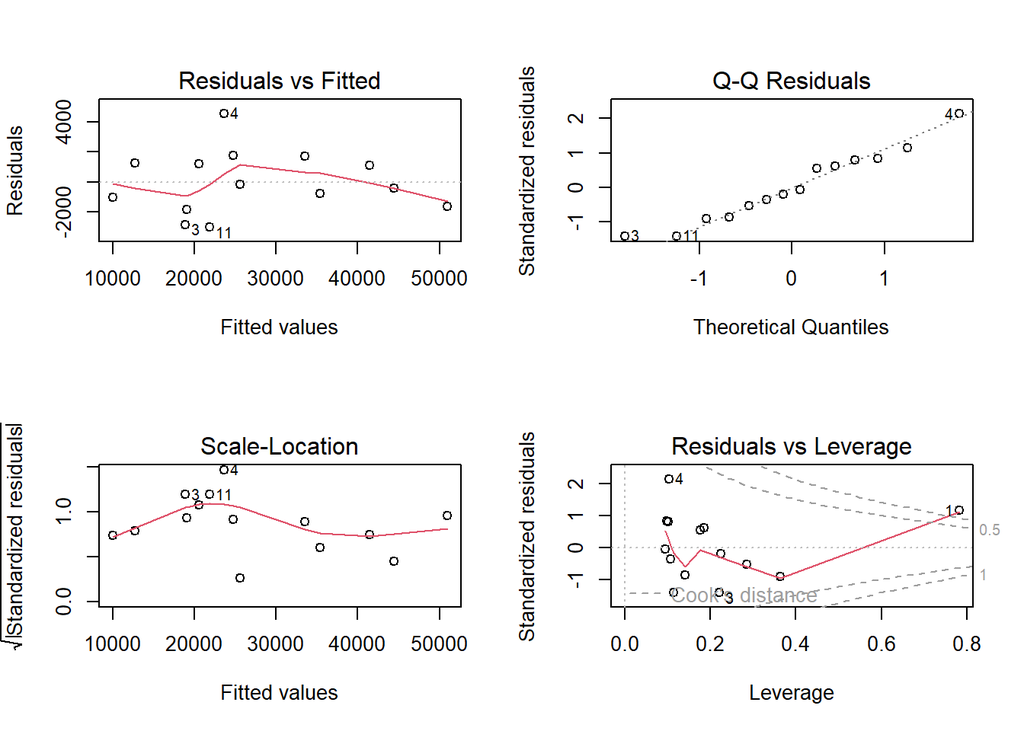

```r
par(mfrow = c(2, 2))
plot(model_lm)
```

Berdasarkan dari grafik model regresi linear diatas, secara keseluruhan dapat disimpulkan bahwa model sudah cukup baik dan sebagian besar asumsi klasik regresi terpenuhi.

## Uji Multikolinearitas

```r
vif(model_lm) # Variance Inflation Factor
```

```
##      Pupuk Luas_tanam
##    294.909    294.909
```

Nilai VIF > 5-10 menunjukkan masalah multikolinearitas.

# Visualisasi

## Plot Efek Marginal

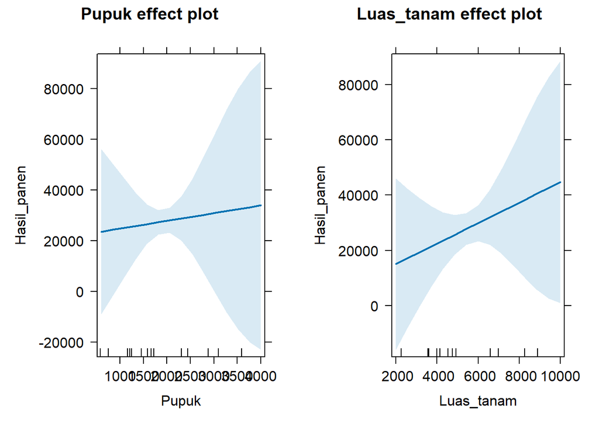

```r
plot(allEffects(model_lm))
```

- Pupuk

  semakin banyak pupuk yang diberikan, maka semakin tinggi hasil panen.
- Luas tanam

  pada grafik luas tanam *effect plot* dapat diketahui bahwa luas tanam yang lebih besar(lebar) maka hasil panen akan lebih tinggi.

# Kesimpulan

1. Regresi linier berganda memungkinkan kita memodelkan hubungan antara beberapa variabel prediktor dengan satu variabel respon
2. Diagnostik model penting untuk memverifikasi asumsi
3. R menyediakan berbagai alat untuk analisis dan visualisasi regresi
4. Representasi matriks membantu memahami mekanisme di balik perhitungan regresi